# Table of Contents

## Continuous variables

```python
df['sqft_living'].describe()
```

```
count   2.2e+04
mean    2.1e+03
std     9.2e+02
min     2.9e+02
25%     1.4e+03
50%     1.9e+03
75%     2.6e+03
max     1.4e+04
Name: sqft_living, dtype: float64
```

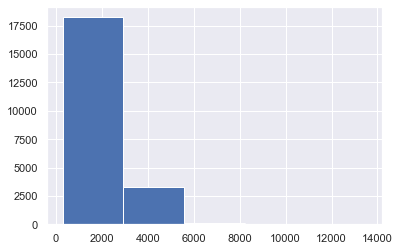

```python
plt.hist('sqft_living', data = df, bins = 5);
```

```python
df.columns
```

```
Index(['id', 'date', 'price', 'bedrooms', 'bathrooms', 'sqft_living',
       'sqft_lot', 'floors', 'waterfront', 'view', 'condition', 'grade',
       'sqft_above', 'sqft_basement', 'yr_built', 'yr_renovated', 'zipcode',
       'lat', 'long', 'sqft_living15', 'sqft_lot15', 'yr_sales', 'age',
       'yr_renovated2', 'age_after_renovation', 'zipcode_top10',
       'zipcode_houses', 'basement_bool', 'renovation_bool', 'age_cat',
       'age_after_renovation_cat', 'waterfront_0', 'waterfront_1', 'view_0',
       'view_1', 'view_2', 'view_3', 'view_4', 'condition_1', 'condition_2',
       'condition_3', 'condition_4', 'condition_5', 'grade_1', 'grade_10',
       'grade_11', 'grade_12', 'grade_13', 'grade_3', 'grade_4', 'grade_5',
       'grade_6', 'grade_7', 'grade_8', 'grade_9', 'zipcode_top10_98004',
       'zipcode_top10_98006', 'zipcode_top10_98033', 'zipcode_top10_98039',
       'zipcode_top10_98040', 'zipcode_top10_98102', 'zipcode_top10_98105',
       'zipcode_top10_98155', 'zipcode_top10_98177', 'zipcode_top10_others',
       'age_cat_0', 'age_cat_1', 'age_cat_2', 'age_cat_3', 'age_cat_4',
       'age_cat_5', 'age_cat_6', 'age_cat_7', 'age_cat_8', 'age_cat_9',
       'age_after_renovation_cat_0', 'age_after_renovation_cat_1',
       'age_after_renovation_cat_2', 'age_after_renovation_cat_3',
       'age_after_renovation_cat_4', 'age_after_renovation_cat_5',
       'age_after_renovation_cat_6', 'age_after_renovation_cat_7',
       'age_after_renovation_cat_8', 'age_after_renovation_cat_9',
       'log1p_price', 'log1p_sqft_living', 'log1p_sqft_lot',
       'log1p_sqft_above', 'log1p_sqft_basement', 'log1p_sqft_living15',
       'log1p_sqft_lot15'],
      dtype='object')
```

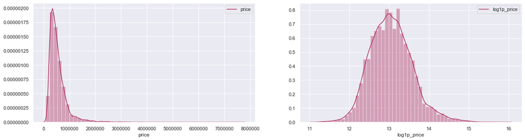

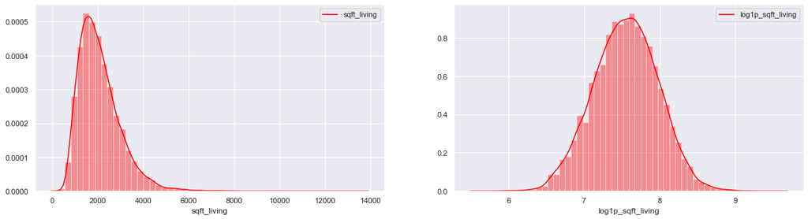

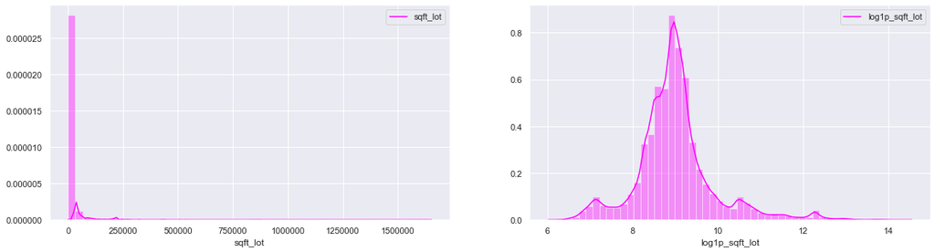

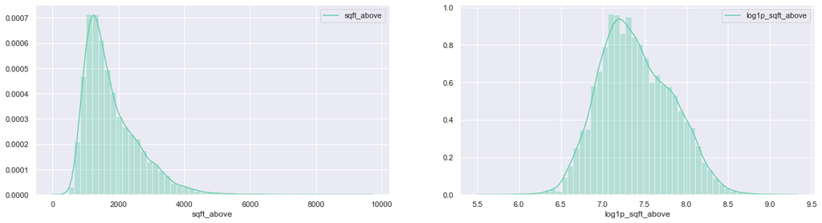

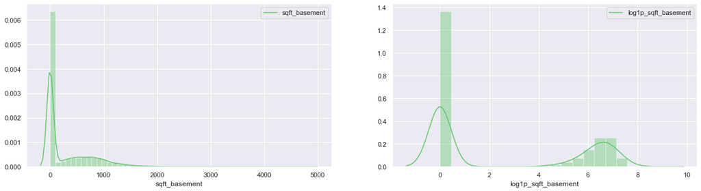

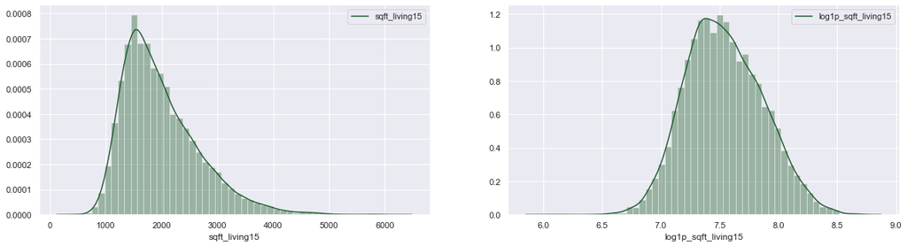

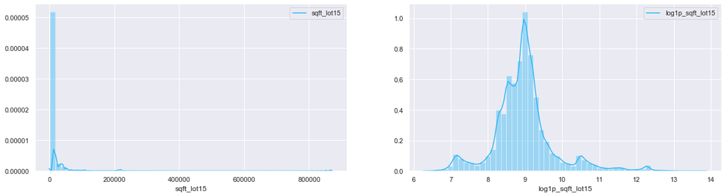

```python
cols_logs = ['price', 'sqft_living', 'sqft_lot',
             'sqft_above','sqft_basement', 'sqft_living15',
             'sqft_lot15']

colors10_hex = ['#b03060','#ff0000', '#ff00ff',
                '#67ceab', '#63c56c', '#225e31',
                 '#29b6f6', '#6495ed','#00008b',
                '#ffa500']

for i,c in enumerate(cols_logs):
    fig = plt.figure(figsize=(20,5))
    plt.subplot(1, 2, 1)
    sns.distplot(df[c], hist=True, kde=True, rug=False,
                 norm_hist=True, kde_kws={"label": c},
                 color=colors10_hex[i])

    # add another plot
    plt.subplot(1, 2, 2)
    sns.distplot(df['log1p_'+c], hist=True, kde=True, rug=False,
                 norm_hist=True, kde_kws={"label": "log1p_"+c},
                 color=colors10_hex[i])

    plt.show()
```

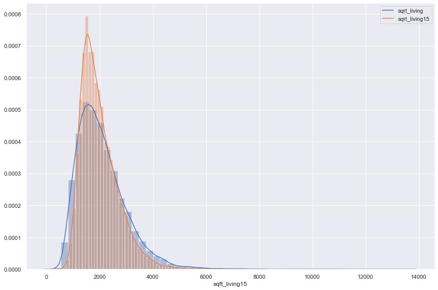

```python
plt.figure(figsize=(12,8))
sns.distplot(df['sqft_living'], hist=True, kde=True, rug=False,
             norm_hist=True, kde_kws={"label": "sqrt_living"})

sns.distplot(df['sqft_living15'], hist=True, kde=True, rug=False,
              norm_hist=True,kde_kws={"label": "sqrt_living15"})

plt.tight_layout()
plt.savefig('../reports/figures/sqft_living_distplot.png')
```

# Categorical variables

Variables such as district names, country names, class names etc are categorical variables. Sometimes discrete variables like #bedrooms #floors can be treated as categorical variables.

When a categorical variable has a class less than 1% of the data, this may cause overfitting and we may want to rename it to RARE and may also drop these rows.

## waterfront

```python
df['waterfront'].value_counts()
```

```
0    21450
1      163
Name: waterfront, dtype: int64
```

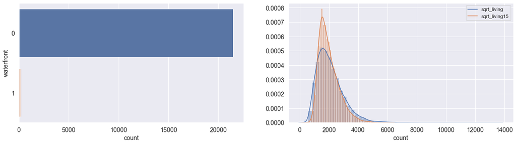

```python
fig = plt.figure(figsize=(20,5))
plt.subplot(1, 2, 1)
ax0= sns.countplot(y="waterfront", data=df)

# add another plot
plt.subplot(1, 2, 2)
sns.distplot(df['sqft_living'], hist=True, kde=True, rug=False,
             norm_hist=True, kde_kws={"label": "sqrt_living"})

ax1 = sns.distplot(df['sqft_living15'], hist=True, kde=True, rug=False,
              norm_hist=True,kde_kws={"label": "sqrt_living15"})

ax0.tick_params(axis='both', which='both', labelsize=14)
ax1.tick_params(axis='both', which='both', labelsize=14)

ax0.set_ylabel('waterfront',fontsize=14)
ax0.set_xlabel('count',fontsize=14)
ax1.set_ylabel('')
ax1.set_xlabel('count',fontsize=14)


# plt.tight_layout()
plt.show()
```

```python
# [ i for i in dir(ax0) if i[:3]=='set']
```

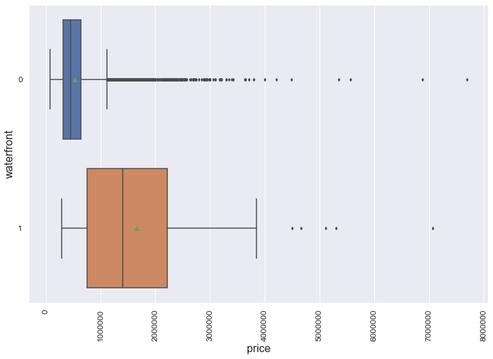

```python
plt.figure(figsize=(12,8))
sns.boxplot(y = 'waterfront', x = 'price', data = df,width = 0.8,
            orient = 'h', showmeans = True, fliersize = 3)

plt.xticks(rotation=90,fontsize=12)
plt.yticks(fontsize=12)

plt.xlabel('price', fontsize=16)
plt.ylabel('waterfront', fontsize=16)

plt.savefig('../reports/figures/waterfront_boxplots.png')
```

```python
# Calculate the correlation coefficient
r, p = stats.pointbiserialr(df['waterfront'], df['price'])
print ('point biserial correlation r is {:.2f} with p = {:.2f}'.format(r,p))
```

```
point biserial correlation r is 0.27 with p = 0.00
```

Observation

- Houses with no waterfront are less spread, their prices are similar.
- Houses with waterfront are widely spread, thier prices are diverse.
- Houses with waterfront have higher price (validated by +ve point-biserial coeff)
- There is little correlation between two waterfronts.

We have not tested the assumptions of point-biserial correlation

- There should be no significant outliers in the two groups of the dichotomous variable in terms of the continuous variable.
- There should be homogeneity of variances.
- The continuous variable should be approximately normally distributed for each group of the dichotomous variable.

## basement_bool

```
point biserial correlation r is 0.18 with p = 0.00
```

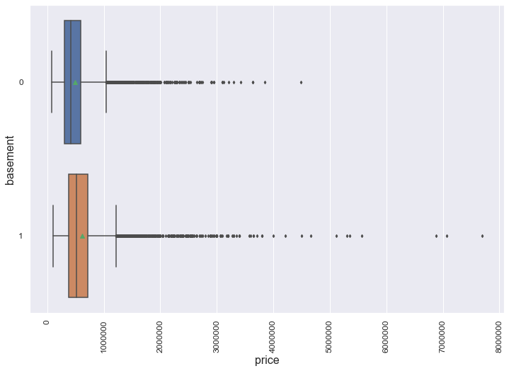

```python
plt.figure(figsize=(12,8))
sns.boxplot(y = 'basement_bool', x = 'price', data = df,width = 0.8,
            orient = 'h', showmeans = True, fliersize = 3)

plt.xticks(rotation=90,fontsize=12)
plt.yticks(fontsize=12)

plt.xlabel('price', fontsize=16)
plt.ylabel('basement', fontsize=16)

plt.savefig('../reports/figures/basement_boxplots.png')

r, p = stats.pointbiserialr(df['basement_bool'], df['price'])
print ('point biserial correlation r is {:.2f} with p = {:.2f}'.format(r,p))
```

## renovation_bool

```
point biserial correlation r is 0.13 with p = 0.00
```

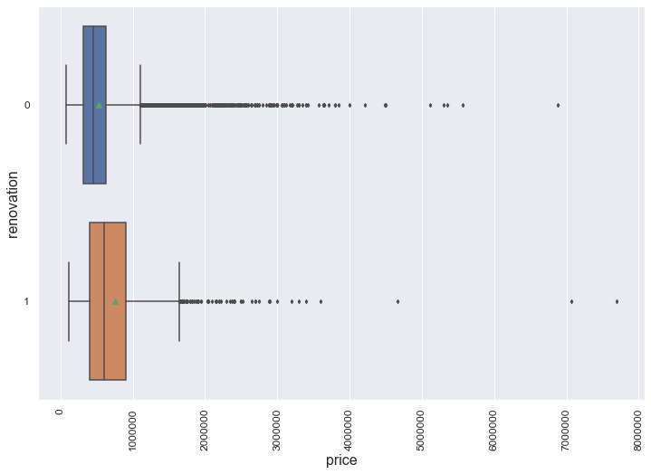

```python
plt.figure(figsize=(12,8))
sns.boxplot(y = 'renovation_bool', x = 'price', data = df,width = 0.8,
            orient = 'h', showmeans = True, fliersize = 3)

plt.xticks(rotation=90,fontsize=12)
plt.yticks(fontsize=12)

plt.xlabel('price', fontsize=16)
plt.ylabel('renovation', fontsize=16)

plt.savefig('../reports/figures/renovation_boxplots.png')

r, p = stats.pointbiserialr(df['renovation_bool'], df['price'])
print ('point biserial correlation r is {:.2f} with p = {:.2f}'.format(r,p))
```

## box plots of categorical features

```python
cols_cat = ['bedrooms' ,'bathrooms',
            'floors', 'view',
            'condition','grade']
```

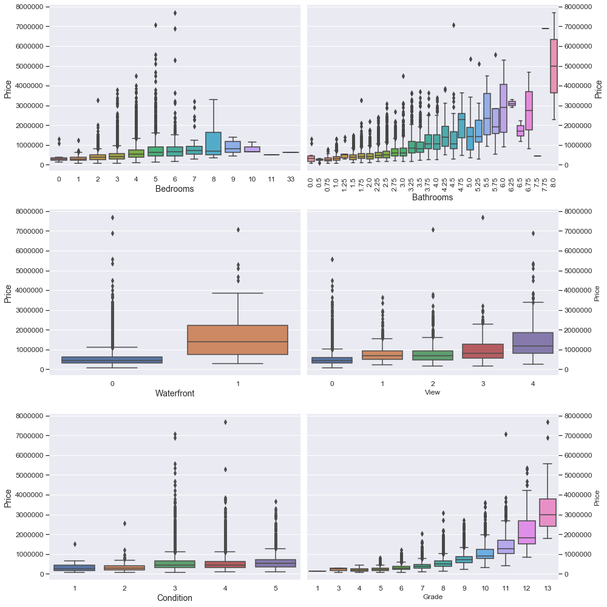

```python
f, ax = plt.subplots(3, 2,figsize=(14,14))

sns.boxplot(x=df['bedrooms'],y=df['price'], ax=ax[0][0])
sns.boxplot(x=df['bathrooms'],y=df['price'], ax=ax[0][1])
sns.boxplot(x=df['waterfront'],y=df['price'], ax=ax[1][0])
sns.boxplot(x=df['view'],y=df['price'], ax=ax[1][1])
sns.boxplot(x=df['condition'],y=df['price'], ax=ax[2][0])
sns.boxplot(x=df['grade'],y=df['price'], ax=ax[2][1])


sns.despine(left=True, bottom=True)


ax[0][0].set_xlabel('Bedrooms', fontsize=14)
ax[0][0].set_ylabel('Price', fontsize=14)
ax[0][0].tick_params(axis='x', labelsize=12)
ax[0][0].tick_params(axis='y', labelsize=12)
ax[0][0].yaxis.tick_left()
ax[0][1].yaxis.set_label_position("right")

ax[0][1].yaxis.tick_right()
ax[0][1].set_xlabel('Bathrooms', fontsize=14)
ax[0][1].set_ylabel('Price', fontsize=14)
ax[0][1].tick_params(axis='x', labelsize=12)
ax[0][1].tick_params(axis='y', labelsize=12)
ax[0][1].set_xticklabels(ax[0][1].get_xticklabels(),rotation=90)

ax[1][0].set_xlabel('Waterfront', fontsize=14)
ax[1][0].set_ylabel('Price', fontsize=14)
ax[1][0].tick_params(axis='x', labelsize=12)
ax[1][0].tick_params(axis='y', labelsize=12)
ax[1][0].yaxis.tick_left()
ax[1][1].yaxis.set_label_position("right")
ax[1][1].yaxis.tick_right()
ax[1][1].set(xlabel='View', ylabel='Price')
ax[1][1].tick_params(axis='x', labelsize=12)
ax[1][1].tick_params(axis='y', labelsize=12)


ax[2][0].set_xlabel('Condition', fontsize=14)
ax[2][0].set_ylabel('Price', fontsize=14)
ax[2][0].tick_params(axis='x', labelsize=12)
ax[2][0].tick_params(axis='y', labelsize=12)
ax[2][0].yaxis.tick_left()
ax[2][1].yaxis.set_label_position("right")
ax[2][1].yaxis.tick_right()
ax[2][1].set(xlabel='Grade', ylabel='Price')
ax[2][1].tick_params(axis='x', labelsize=12)
ax[2][1].tick_params(axis='y', labelsize=12)

plt.tight_layout()
plt.savefig('../reports/figures/categorical_features_boxplots.png')
```

```python
df.columns
```

```
Index(['id', 'date', 'price', 'bedrooms', 'bathrooms', 'sqft_living',
       'sqft_lot', 'floors', 'waterfront', 'view', 'condition', 'grade',
       'sqft_above', 'sqft_basement', 'yr_built', 'yr_renovated', 'zipcode',
       'lat', 'long', 'sqft_living15', 'sqft_lot15', 'yr_sales', 'age',
       'yr_renovated2', 'age_after_renovation', 'zipcode_top10',
       'zipcode_houses', 'basement_bool', 'renovation_bool', 'age_cat',
       'age_after_renovation_cat', 'waterfront_0', 'waterfront_1', 'view_0',
       'view_1', 'view_2', 'view_3', 'view_4', 'condition_1', 'condition_2',
       'condition_3', 'condition_4', 'condition_5', 'grade_1', 'grade_10',
       'grade_11', 'grade_12', 'grade_13', 'grade_3', 'grade_4', 'grade_5',
       'grade_6', 'grade_7', 'grade_8', 'grade_9', 'zipcode_top10_98004',
       'zipcode_top10_98006', 'zipcode_top10_98033', 'zipcode_top10_98039',
       'zipcode_top10_98040', 'zipcode_top10_98102', 'zipcode_top10_98105',
       'zipcode_top10_98155', 'zipcode_top10_98177', 'zipcode_top10_others',
       'age_cat_0', 'age_cat_1', 'age_cat_2', 'age_cat_3', 'age_cat_4',
       'age_cat_5', 'age_cat_6', 'age_cat_7', 'age_cat_8', 'age_cat_9',
       'age_after_renovation_cat_0', 'age_after_renovation_cat_1',
       'age_after_renovation_cat_2', 'age_after_renovation_cat_3',
       'age_after_renovation_cat_4', 'age_after_renovation_cat_5',
       'age_after_renovation_cat_6', 'age_after_renovation_cat_7',
       'age_after_renovation_cat_8', 'age_after_renovation_cat_9',
       'log1p_price', 'log1p_sqft_living', 'log1p_sqft_lot',
       'log1p_sqft_above', 'log1p_sqft_basement', 'log1p_sqft_living15',
       'log1p_sqft_lot15'],
      dtype='object')
```

```python
stats.spearmanr(df['bedrooms'],df['price'])
```

```
SpearmanrResult(correlation=0.34465237095978885, pvalue=0.0)
```

```python
stats.spearmanr(df['floors'],df['price'])
```

```
SpearmanrResult(correlation=0.32234655003563695, pvalue=0.0)
```

```python
(df[['bedrooms','floors','view','condition','grade']]
 .corrwith(df['price'],method='spearman')
 .rename('spearmanr').rename_axis('column').reset_index())
```

|  | column | spearmanr |
| --- | --- | --- |
| 0 | bedrooms | 0.34 |
| 1 | floors | 0.32 |
| 2 | view | 0.29 |
| 3 | condition | 0.018 |
| 4 | grade | 0.66 |

# Bi-variate Analysis

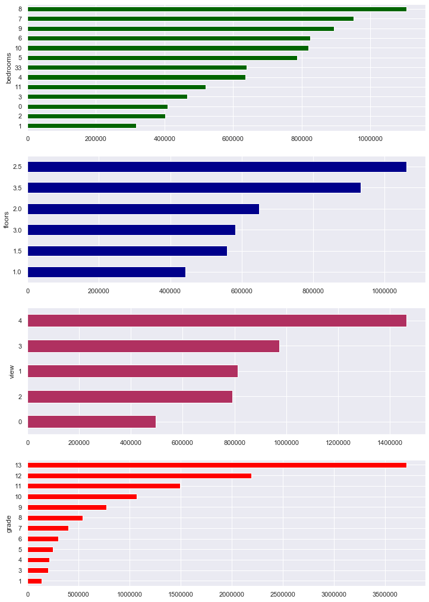

```python
colors = ['#006400', '#00008b', '#b03060',
                '#ff0000', '#ffff00', '#00ff00',
                '#00ffff', '#ff00ff', '#6495ed', '#ffdead']

fig,ax= plt.subplots(4,1, figsize=(12,18))
df.groupby(['bedrooms'])['price'].mean().sort_values().plot.barh(color=colors[0],ax=ax[0])
df.groupby(['floors'])['price'].mean().sort_values().plot.barh(color=colors[1],ax=ax[1])
df.groupby(['view'])['price'].mean().sort_values().plot.barh(color=colors[2],ax=ax[2])
df.groupby(['grade'])['price'].mean().sort_values().plot.barh(color=colors[3],ax=ax[3])
plt.savefig('../reports/figures/categorical_variables_barh_plots.png', dpi=300)
```

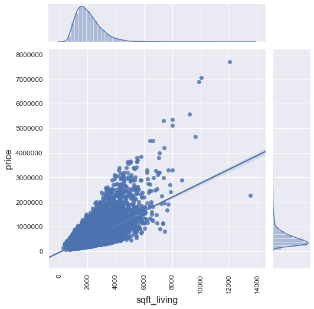

```python
sns.jointplot(x="sqft_living", y="price", data=df, kind='reg', height=7)

plt.xticks(rotation=90,fontsize=12)
plt.yticks(fontsize=12)

plt.xlabel('sqft_living', fontsize=16)
plt.ylabel('price', fontsize=16)

plt.savefig('../reports/figures/sqft_living_vs_price_jointplot.png', dpi=300)
```

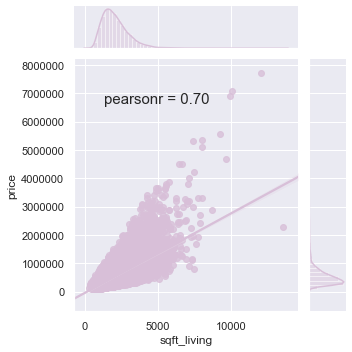

```python
from bhishan.util_viz import colors


def multiple_jointplots_with_pearsonr(cols,target):
    import scipy
    for i,col in enumerate(cols):
        p = sns.jointplot(x=col, y=target, data=df, kind='reg',
                          height=5 ,color=colors[i])
        r, _ = scipy.stats.pearsonr(df[col].values, df[target].values)
        p.fig.text(0.3, 0.7, "pearsonr = {:.2f}".format(r), ha ='left',
                   fontsize = 15)
        return plt

cols = ['sqft_living', 'sqft_living15', 'sqft_above']
multiple_jointplots_with_pearsonr(cols,'price')
plt.tight_layout()
plt.savefig('../reports/figures/multiple_jointplots_with_pearsonr.png',dpi=300)
```

Observation:

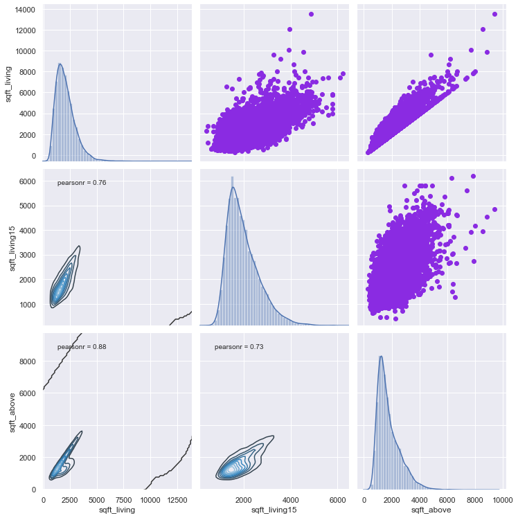

```python
from bhishan.util_viz import corrplot_with_pearsonr

cols = ['sqft_living', 'sqft_living15', 'sqft_above']
corrplot_with_pearsonr(df,cols,ofile='../reports/figures/corrplot_with_pearsonr.png')
```

Observation

- There is strong relationship among 3 variables (r>0.7).
- sqft_above = sqft_livng - sqft_basement.
- sqft_living15 is strongly related to price.
- sqft_living15 is strongly related to sqft_above.
- We do not know sqft_living15 is partially correlated with price or not.

```python
from bhishan.util_stats import partial_corr

cols = ['price', 'sqft_living', 'sqft_living15']
partial_corr(df,cols)
```

|  | price | sqft_living | sqft_living15 |
| --- | --- | --- | --- |
| price | 1 | 0.48 | 0.063 |
| sqft_living | 0.48 | 1 | 0.78 |
| sqft_living15 | 0.063 | 0.78 | 1 |

```python
df[cols].corr(method='pearson') # full correlations.
```

|  | price | sqft_living | sqft_living15 |
| --- | --- | --- | --- |
| price | 1 | 0.7 | 0.59 |
| sqft_living | 0.7 | 1 | 0.76 |
| sqft_living15 | 0.59 | 0.76 | 1 |

```python
stats.pearsonr(df['sqft_living'], df['price'])
```

```
(0.7020350546118002, 0.0)
```

```python
stats.pearsonr(df['sqft_living15'], df['price'])
```

```
(0.585378903579568, 0.0)
```

Observation